# Batch_variable_evaluation_visualisation

Author

Pakorn Sagulkoo

Following the previous step, where the Harmony package was employed to integrate single-cell datasets for CLL and RT across several studies, we corrected batch effects using several variables, including case_id (sample ID), ref (studies), and patient (cases). We computed a series of metrics, specifically LISI, kBET, cASW, and PCRegression, to evaluate which variables yielded the optimal balance between batch-effect removal and biological structure conservation. The subsequent code serves to visualise these results.

# Import the relevant packages and set working path directory

```r
# Attach the packages you will need for the analysis.
library(Seurat)
library(harmony)
library(SingleR)
library(celldex)
library(sctransform)
library(ggsci)
library(tidyverse)
library(dplyr)
library(data.table)
library(kBET)
library(FNN)
library(lisi)
library(cluster)
library(stats)
library(DescTools)
```

```r
# Check root path
here::here()
```

```
[1] "/mnt/hp-storage/users/pakorns"
```

# Define paths

```r
# Define paths to load and save
path_to_obj <- here::here("scRNAseq/meta_analysis/R_objects")
path_to_lisi_df <- paste0(path_to_obj, "/lisi_df.rds")
path_to_kbet_df <- paste0(path_to_obj, "/kbet_df.rds")
path_to_sil_df <- paste0(path_to_obj, "/sil_df.rds")
path_to_pcr_df <- paste0(path_to_obj, "/pcr_df.rds")
path_to_save_figure <- here::here("figures")
```

# Load data and functions

```r
# Source functions
source(here::here("bin/utils.R"))
```

```r
# Load the result data frames
lisi_df <- readRDS(path_to_lisi_df)
kbet_df <- readRDS(path_to_kbet_df)
sil_df <- readRDS(path_to_sil_df)
pcr_df <- readRDS(path_to_pcr_df)
```

# Colour and name preparation

```r
# Set label and colour pallete
variable_map <- c(
  "sample"       = "Sample",
  "ref"          = "Study",
  "case"         = "Patient",
  "sample_ref"   = "Sample+Study",
  "sample_case"  = "Sample+Patient",
  "ref_case"     = "Study+Patient",
  "all"          = "All variables"
)

variable_cols <- c(
  "Sample"        = "#F05C3B",
  "Study"         = "#197EC0",
  "Patient"       = "#C80813",
  "Sample+Study"  = "#FD8CC1",
  "Study+Patient" = "#46732E",
  "All variables" = "#FFB900"
)
```

# Batch removal and biological conservation performance

## LISI

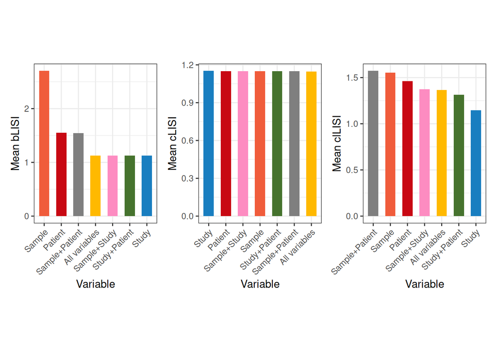

```r
# Plot mean LISI scores
lisi_df <- lisi_df %>% dplyr::mutate(variable = variable_map[dataset])

## bLISI score
mean_blisi.plt <- lisi_df %>%
  dplyr::select(c("bLISI", "variable")) %>%
  dplyr::group_by(variable) %>%
  dplyr::summarize(mean_bLISI = mean(bLISI)) %>%
  dplyr::mutate(variable = fct_reorder(as.factor(variable), mean_bLISI, .desc=TRUE)) %>%
  ggplot(aes(x=variable, y=mean_bLISI, fill=variable)) +
  geom_col(width = 0.6) +
  xlab("Variable") +
  ylab("Mean bLISI") +
  scale_fill_manual(values = variable_cols) +
  theme_bw() +
  theme(aspect.ratio = 1.3,
        legend.position = "none",
        axis.text.x = element_text(angle=45, hjust=1))

## cLISI score
mean_clisi.plt <- lisi_df %>%
  dplyr::select(c("cLISI", "variable")) %>%
  dplyr::group_by(variable) %>%
  dplyr::summarize(mean_cLISI = mean(cLISI)) %>%
  dplyr::mutate(variable = fct_reorder(as.factor(variable), mean_cLISI, .desc=TRUE)) %>%
  ggplot(aes(x=variable, y=mean_cLISI, fill=variable)) +
  geom_col(width = 0.6) +
  xlab("Variable") +
  ylab("Mean cLISI") +
  scale_fill_manual(values = variable_cols) +
  theme_bw() +
  theme(aspect.ratio = 1.3,
        legend.position = "none",
        axis.text.x = element_text(angle=45, hjust=1))

## clLISI score
mean_cllisi.plt <- lisi_df %>%
  dplyr::select(c("clLISI", "variable")) %>%
  dplyr::group_by(variable) %>%
  dplyr::summarize(mean_clLISI = mean(clLISI)) %>%
  dplyr::mutate(variable = fct_reorder(as.factor(variable), mean_clLISI, .desc=TRUE)) %>%
  ggplot(aes(x=variable, y=mean_clLISI, fill=variable)) +
  geom_col(width = 0.6) +
  xlab("Variable") +
  ylab("Mean clLISI") +
  scale_fill_manual(values = variable_cols) +
  theme_bw() +
  theme(aspect.ratio = 1.3,
        legend.position = "none",
        axis.text.x = element_text(angle=45, hjust=1))

mean_lisi.plt <- mean_blisi.plt + mean_clisi.plt + mean_cllisi.plt
mean_lisi.plt
```

```r
# Save the figures
ggsave(filename=paste0(path_to_save_figure, "/harmony_blisi.png"), plot=mean_blisi.plt, dpi=500, height=3, width=4.5)
ggsave(filename=paste0(path_to_save_figure, "/harmony_clisi.png"), plot=mean_clisi.plt, dpi=500, height=3, width=4.5)
ggsave(filename=paste0(path_to_save_figure, "/harmony_cllisi.png"), plot=mean_cllisi.plt, dpi=500, height=3, width=4.5)
```

From the LISI scores, we found that `Sample` variable provided the highest bLISI score (2.70), following with `Patient` (1.55), `Sample+Patient` (1.54), and `All variables` (1.13). `Study` and `Study+Patient` variables had the lowest bLISI scores (1.12). All measured variables had the same cLISI at 1.15. For clLISI scores, `Sample+Patient` had the highest value at 1.57, following with `Sample` (1.55), `Patient` (1.46), `Sample+Study` and `All variables` (1.37), and `Study+Patient` (1.31). `Study` variable provided the lowest clLISI score at 1.15.

## kBET

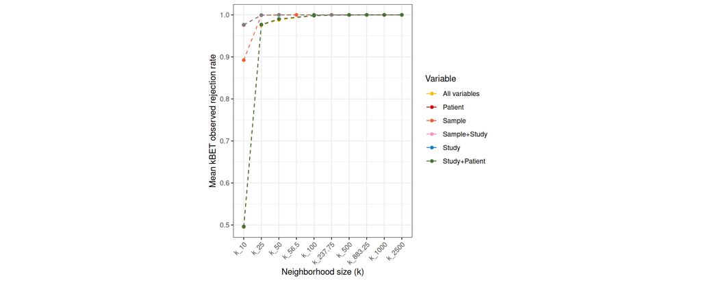

```r
# Plot kBET observed rejection rates curve
k_levels <- c("k_10", "k_25", "k_50", "k_56.5", "k_100", "k_237.75", "k_500", "k_883.25", "k_1000", "k_2500")

kbet_df <- kbet_df %>%
  dplyr::mutate(variable = variable_map[dataset]) %>%
  # Ensure k is an ordered factor before summarising
  dplyr::mutate(k_ordered = factor(k, levels = k_levels))

kbet_rates_curve.plt = kbet_df %>%
  dplyr::filter(class == "observed") %>%
  dplyr::group_by(variable, k_ordered) %>% # Group by the new ordered factor
  dplyr::summarize(mean_obs_rejection_rate = mean(data), .groups = "drop") %>%
  ggplot(aes(x=k_ordered,
              y=mean_obs_rejection_rate,
              color=variable)) +
  geom_line(aes(y=mean_obs_rejection_rate, group=variable),
            linetype="dashed") +
  geom_point(size=1.5) +
  labs(x="Neighborhood size (k)",
       y="Mean kBET observed rejection rate",
       color="Variable") +
  theme_bw() +
  theme(aspect.ratio = 1.3,
        legend.position = "right",
        axis.text.x = element_text(angle=45, hjust=1)) + # Added angle for readability
  scale_color_manual(values= variable_cols)

kbet_rates_curve.plt
```

```r
# Save the figures
ggsave(filename=paste0(path_to_save_figure, "/harmony_kbet.png"), plot=kbet_rates_curve.plt, dpi=500, height=5, width=5.5)
```

```r
# Calculate AUC in each method
auc.lst <- list()
variables <- c("Sample", "Study", "Patient", "Sample+Study", "Sample+Patient", "Study+Patient", "All variables")

for (i in seq_along(variables)) {

  # Keep only observed rejection rates and compute means
  sorted_rej_rates <- kbet_df %>%
    dplyr::filter(class == "observed" & variable == variables[i]) %>%
    dplyr::group_by(variable, k) %>%
    dplyr::summarize(mean_obs_rejection_rate = mean(data), .groups = "drop") %>%
    dplyr::arrange(mean_obs_rejection_rate) %>%
    dplyr::mutate(k_index = seq(1, length(unique(k)), by=1))

  # Calculate AUC
  auc <- DescTools::AUC(x=sorted_rej_rates$k_index,
                       y=sorted_rej_rates$mean_obs_rejection_rate,
                       method="spline")
  auc.lst[[i]] <- auc
  names(auc.lst)[i] <- variables[i]

}

auc.lst
```

```
$Sample
[1] 6.956588

$Study
[1] 6.764062

$Patient
[1] 6.989896

$`Sample+Study`
[1] 6.764153

$`Sample+Patient`
[1] 6.990039

$`Study+Patient`
[1] 6.764087

$`All variables`
[1] 6.759225
```

For the AUC, `All variables` provided the lowest value at 6.759225, following with `Study` at 6.764062. While `Sample+Patient` had the greatest value at 6.990039.

## cASW

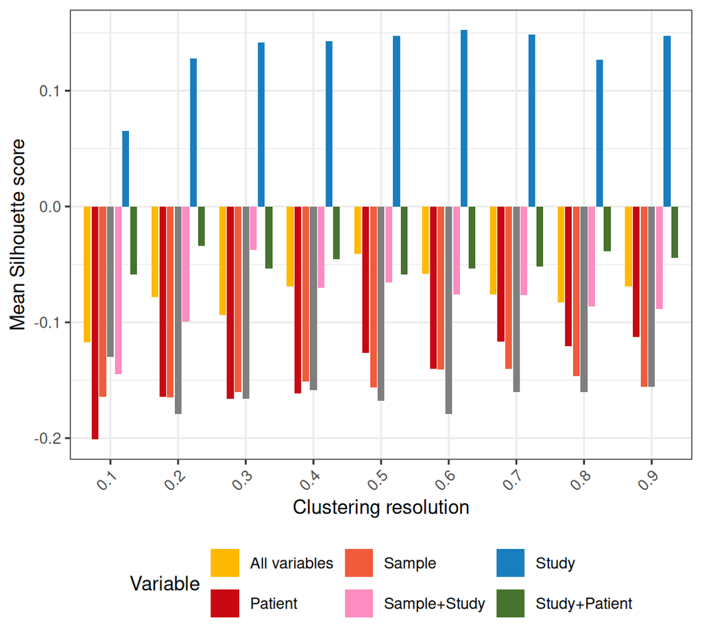

```r
# Plot silhouette scores
sil_df <- sil_df %>% dplyr::mutate(variable = variable_map[dataset])

sil_scores.plt <- sil_df %>%
  dplyr::group_by(res, variable) %>%
  dplyr::summarise(mean_sil = mean(sil_width), .groups = "drop") %>%
  ggplot(aes(x = factor(res), y = mean_sil, fill = variable)) +
  geom_col(position = position_dodge(width = 0.8), width = 0.7) +
  xlab("Clustering resolution") +
  ylab("Mean Silhouette score") +
  scale_fill_manual(values = variable_cols) +
  theme_bw() +
  theme(
    axis.text.x = element_text(angle = 45, hjust = 1),
    legend.position = "bottom"
  ) +
  labs(fill = "Variable")

sil_scores.plt
```

```r
# Save the figures
ggsave(filename=paste0(path_to_save_figure, "/harmony_sil.png"), plot=sil_scores.plt, dpi=500, height=5, width=5.5)
```

From the cASW results, only `Study` variable provided the positive value for all resolution, indicating biological structure preservation. Batch removal based on other variables could over correct as all cASW values were negative.

## PCRegression

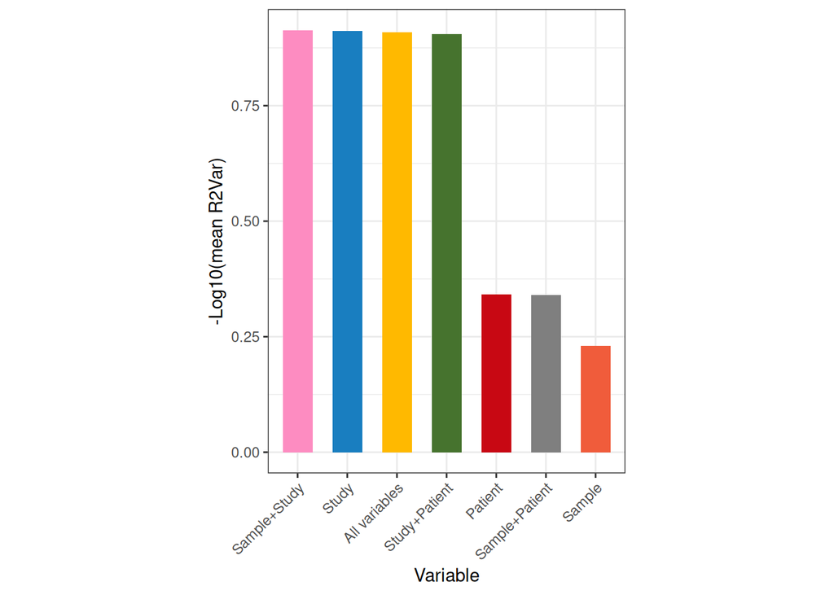

```r
# Plot the -log10 values of variance explained by batch effects
pcr_df <- pcr_df %>% dplyr::mutate(variable = variable_map[dataset])

r2var.plt <- pcr_df %>%
  dplyr::group_by(variable) %>%
  dplyr::summarise(mean_R2Var = mean(R2Var), .groups = "drop") %>%
  dplyr::mutate(variable=fct_reorder(variable, -log10(mean_R2Var), .desc=TRUE)) %>%
  ggplot(aes(x=variable, y=-log10(mean_R2Var), fill=variable)) +
  geom_col(width = 0.6) +
  xlab("Variable") +
  ylab("-Log10(mean R2Var)") +
  scale_fill_manual(values = variable_cols) +
  theme_bw() +
  theme(aspect.ratio = 1.3,
        legend.position = "none",
        axis.text.x = element_text(angle = 45, hjust=1))

r2var.plt
```

```r
# Save the figures
ggsave(filename=paste0(path_to_save_figure, "/harmony_r2var.png"), plot=r2var.plt, dpi=500, height=3, width=4.5)
```

From the plots, it was observed that `Sample+Study` and `Study` provided the highest negative logarithmic *R<sup>2</sup>* variance, following with `All variables`, `Study+Patient`, `Patient`, `Sample+Patient`, and `Sample`.

When considering both batch removal and biological conservation through the metrices, the seurat object using Harmony with batch correction based on `Study` variable is the best option for further downstream analysis.